# train_tag

Patricia Yin

09/02/2021

# I. Exploratory Data Analysis

load and view train_tag.csv dataset provided by a Chinese bank in a modelling competition.

```r
library(tidyverse)
```

```r
library(ggplot2)

tag <- read.csv("train_tag.csv")
dim(tag)[1]
```

```
## [1] 40000
```

```r
colnames(tag)
```

```
##  [1] "id"                              "flag"
##  [3] "gdr_cd"                          "age"
##  [5] "mrg_situ_cd"                     "edu_deg_cd"
##  [7] "acdm_deg_cd"                     "deg_cd"
##  [9] "job_year"                        "ic_ind"
## [11] "fr_or_sh_ind"                    "dnl_mbl_bnk_ind"
## [13] "dnl_bind_cmb_lif_ind"            "hav_car_grp_ind"
## [15] "hav_hou_grp_ind"                 "l6mon_agn_ind"
## [17] "frs_agn_dt_cnt"                  "vld_rsk_ases_ind"
## [19] "fin_rsk_ases_grd_cd"             "confirm_rsk_ases_lvl_typ_cd"
## [21] "cust_inv_rsk_endu_lvl_cd"        "l6mon_daim_aum_cd"
## [23] "tot_ast_lvl_cd"                  "pot_ast_lvl_cd"
## [25] "bk1_cur_year_mon_avg_agn_amt_cd" "l12mon_buy_fin_mng_whl_tms"
## [27] "l12_mon_fnd_buy_whl_tms"         "l12_mon_insu_buy_whl_tms"
## [29] "l12_mon_gld_buy_whl_tms"         "loan_act_ind"
## [31] "pl_crd_lmt_cd"                   "ovd_30d_loan_tot_cnt"
## [33] "his_lng_ovd_day"                 "hld_crd_card_grd_cd"
## [35] "crd_card_act_ind"                "l1y_crd_card_csm_amt_dlm_cd"
## [37] "atdd_type"                       "perm_crd_lmt_cd"
## [39] "cur_debit_cnt"                   "cur_credit_cnt"
## [41] "cur_debit_min_opn_dt_cnt"        "cur_credit_min_opn_dt_cnt"
## [43] "cur_debit_crd_lvl"
```

```r
rdm.index <- sample(dim(tag)[1], size=6)
tag[rdm.index,]
```

```
##           id flag gdr_cd age mrg_situ_cd edu_deg_cd acdm_deg_cd deg_cd job_year
## 28476 U34680    0      M  48           B          M           D              18
## 32900 U30533    0      F  40           B          F           G      ~        0
## 3835  U18155    0      F  41           B          K           G      ~        0
## 8207  U35310    0      F  41           B          B          30               0
## 8851  U12167    0      M  44           B          B          30               1
## 36848 U40564    0      M  42           A          B           Z               5
##       ic_ind fr_or_sh_ind dnl_mbl_bnk_ind dnl_bind_cmb_lif_ind hav_car_grp_ind
## 28476      0            0               1                    1               1
## 32900      0            0               1                    1               0
## 3835       0            0               1                    1               1
## 8207       0            0               1                    1               0
## 8851       0            0               1                    1               1
## 36848      0            0               1                    1               0
##       hav_hou_grp_ind l6mon_agn_ind frs_agn_dt_cnt vld_rsk_ases_ind
```

[output cut: 62 more lines]

```r
summary(tag)
```

```
##         id             flag     gdr_cd         age         mrg_situ_cd
##  U10000  :    1   Min.   :0.0   F:18149   Min.   : 19.00   ~:  213
##  U10001  :    1   1st Qu.:0.0   M:21851   1st Qu.: 38.00   A:10726
##  U10002  :    1   Median :0.0             Median : 42.00   B:28755
##  U1000216:    1   Mean   :0.1             Mean   : 42.99   O:  305
##  U10003  :    1   3rd Qu.:0.0             3rd Qu.: 48.00   Z:    1
##  U10004  :    1   Max.   :1.0             Max.   :119.00
##  (Other) :39994
##    edu_deg_cd    acdm_deg_cd     deg_cd         job_year          ic_ind
##  B      :16093   30:12681    ~      :15304   Min.   : 0.000   Min.   :0.0000
##  C      : 9052   31: 9025           :14502   1st Qu.: 0.000   1st Qu.:0.0000
##  F      : 3820   C : 2987    A      : 4764   Median : 1.000   Median :0.0000
##  A      : 3669   D :  404    B      : 3324   Mean   : 4.449   Mean   :0.1469
##  K      : 3291   F :  623    C      : 1192   3rd Qu.: 6.000   3rd Qu.:0.0000
##  Z      : 2186   G : 5175    Z      :  793   Max.   :90.000   Max.   :1.0000
##  (Other): 1889   Z : 9105    (Other):  121
##   fr_or_sh_ind    dnl_mbl_bnk_ind  dnl_bind_cmb_lif_ind hav_car_grp_ind
##  Min.   :0.0000   Min.   :0.0000   Min.   :0.0000       Min.   :0.0000
##  1st Qu.:0.0000   1st Qu.:1.0000   1st Qu.:1.0000       1st Qu.:0.0000
##  Median :0.0000   Median :1.0000   Median :1.0000       Median :1.0000
##  Mean   :0.3028   Mean   :0.9996   Mean   :0.8361       Mean   :0.6486
##  3rd Qu.:1.0000   3rd Qu.:1.0000   3rd Qu.:1.0000       3rd Qu.:1.0000
##  Max.   :1.0000   Max.   :1.0000   Max.   :1.0000       Max.   :1.0000
##
##  hav_hou_grp_ind   l6mon_agn_ind    frs_agn_dt_cnt vld_rsk_ases_ind
##  Min.   :0.00000   Min.   :0.0000   Min.   :  -1   Min.   :0.0000
##  1st Qu.:0.00000   1st Qu.:0.0000   1st Qu.:  -1   1st Qu.:0.0000
##  Median :0.00000   Median :0.0000   Median : 186   Median :0.0000
##  Mean   :0.09225   Mean   :0.3259   Mean   : 493   Mean   :0.4878
##  3rd Qu.:0.00000   3rd Qu.:1.0000   3rd Qu.:1166   3rd Qu.:1.0000
##  Max.   :1.00000   Max.   :1.0000   Max.   :1278   Max.   :1.0000
##
##  fin_rsk_ases_grd_cd confirm_rsk_ases_lvl_typ_cd cust_inv_rsk_endu_lvl_cd
##  Min.   :-1.0000     Min.   :-1.00               Min.   :1.000
##  1st Qu.:-1.0000     1st Qu.:-1.00               1st Qu.:1.000
##  Median :-1.0000     Median : 2.00               Median :1.000
##  Mean   : 0.8276     Mean   : 1.31               Mean   :2.125
##  3rd Qu.: 3.0000     3rd Qu.: 3.00               3rd Qu.:2.000
##  Max.   :10.0000     Max.   :16.00               Max.   :9.000
##
```

[output cut: 41 more lines]

```
##  Min.   :-1.000   Min.   :  1.000   Min.   : 1.000   Min.   :   2
##  1st Qu.: 4.000   1st Qu.:  1.000   1st Qu.: 1.000   1st Qu.:2362
##  Median : 6.000   Median :  2.000   Median : 1.000   Median :4232
##  Mean   : 5.407   Mean   :  3.591   Mean   : 1.703   Mean   :4027
##  3rd Qu.: 7.000   3rd Qu.:  4.000   3rd Qu.: 2.000   3rd Qu.:5629
##  Max.   : 8.000   Max.   :558.000   Max.   :60.000   Max.   :9663
##
##  cur_credit_min_opn_dt_cnt cur_debit_crd_lvl
##  Min.   :  -1              Min.   :10.0
##  1st Qu.:1713              1st Qu.:10.0
##  Median :3468              Median :20.0
##  Mean   :3128              Mean   :21.1
##  3rd Qu.:4564              3rd Qu.:20.0
##  Max.   :6086              Max.   :80.0
##
```

## 1.1 Data cleaning and prepocessing

```r
#put categorical variables as fators
tag[c(2,3,5,6,7,8,10,11,12,13,14,15,16,18,30,35,37)] <- lapply(tag[c(2,3,5,6,7,8,10,11,12,13,14,15,16,18,30,35,37)], as.factor)
```

columns with -1: frs_agn_dt_cnt, fin_rsk_ases_grd_cd, confirm_rsk_ases_lvl_typ_cd, tot_ast_lvl_cd, pot_ast_lvl_cd, hld_crd_card_grd_cd, perm_crd_lmt_cd, cur_credit_min_opn_dt_cnt

Treat them as missing values and remove rows with -1 in any columns from the dataset

```r
#try to remove -1
colnames(tag)
```

```
##  [1] "id"                              "flag"
##  [3] "gdr_cd"                          "age"
##  [5] "mrg_situ_cd"                     "edu_deg_cd"
##  [7] "acdm_deg_cd"                     "deg_cd"
##  [9] "job_year"                        "ic_ind"
## [11] "fr_or_sh_ind"                    "dnl_mbl_bnk_ind"
## [13] "dnl_bind_cmb_lif_ind"            "hav_car_grp_ind"
## [15] "hav_hou_grp_ind"                 "l6mon_agn_ind"
## [17] "frs_agn_dt_cnt"                  "vld_rsk_ases_ind"
## [19] "fin_rsk_ases_grd_cd"             "confirm_rsk_ases_lvl_typ_cd"
## [21] "cust_inv_rsk_endu_lvl_cd"        "l6mon_daim_aum_cd"
## [23] "tot_ast_lvl_cd"                  "pot_ast_lvl_cd"
## [25] "bk1_cur_year_mon_avg_agn_amt_cd" "l12mon_buy_fin_mng_whl_tms"
## [27] "l12_mon_fnd_buy_whl_tms"         "l12_mon_insu_buy_whl_tms"
## [29] "l12_mon_gld_buy_whl_tms"         "loan_act_ind"
## [31] "pl_crd_lmt_cd"                   "ovd_30d_loan_tot_cnt"
## [33] "his_lng_ovd_day"                 "hld_crd_card_grd_cd"
## [35] "crd_card_act_ind"                "l1y_crd_card_csm_amt_dlm_cd"
## [37] "atdd_type"                       "perm_crd_lmt_cd"
## [39] "cur_debit_cnt"                   "cur_credit_cnt"
## [41] "cur_debit_min_opn_dt_cnt"        "cur_credit_min_opn_dt_cnt"
## [43] "cur_debit_crd_lvl"
```

```r
neg_col_index <- c(17, 19, 20, 23, 24, 34, 38, 42)
dat <- tag
for (i in 1:8) {
  dat <- subset(dat, dat[neg_col_index[i]] != -1)
}

dim(dat)
```

```
## [1] 4629   43
```

```r
dim(tag)
```

```
## [1] 40000    43
```

The reduced dataset is only 1/10 of the original one. Try to investigate why -1 was coded

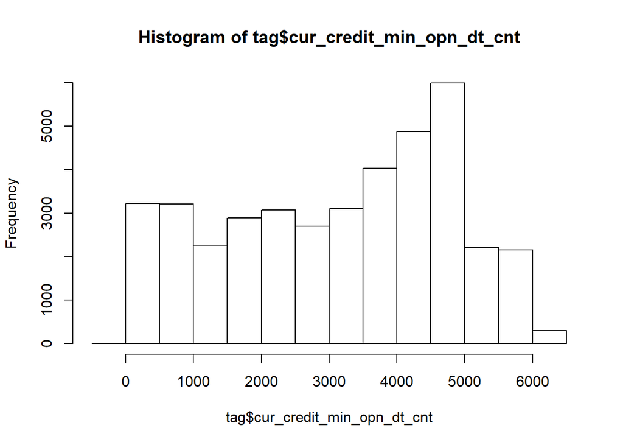

```r
#check cur_credit_min_opn_dt_cnt
hist(tag$cur_credit_min_opn_dt_cnt)
```

```r
summary(tag$cur_credit_cnt)
```

```
##    Min. 1st Qu.  Median    Mean 3rd Qu.    Max.
##   1.000   1.000   1.000   1.703   2.000  60.000
```

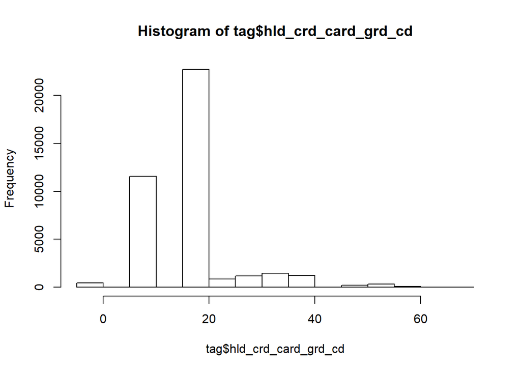

```r
#remove rows with -1 in cur_credit_min_opn_dt_cnt
dat1 <- subset(tag, cur_credit_min_opn_dt_cnt != -1)

#check hld_crd_card_grd_cd
hist(tag$hld_crd_card_grd_cd)
```

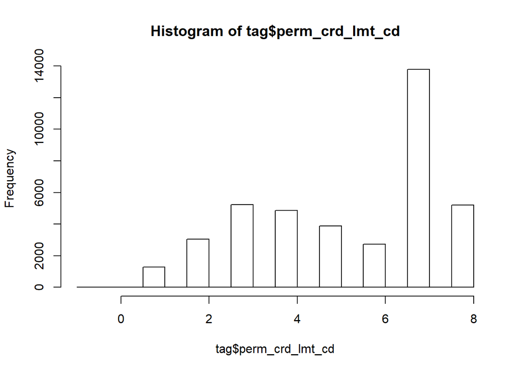

```r
#remove -1 in hld_crd_card_grd_cd
dat1 <- subset(dat1, hld_crd_card_grd_cd != -1)

#check perm_crd_lmt_cd
hist(tag$perm_crd_lmt_cd)
```

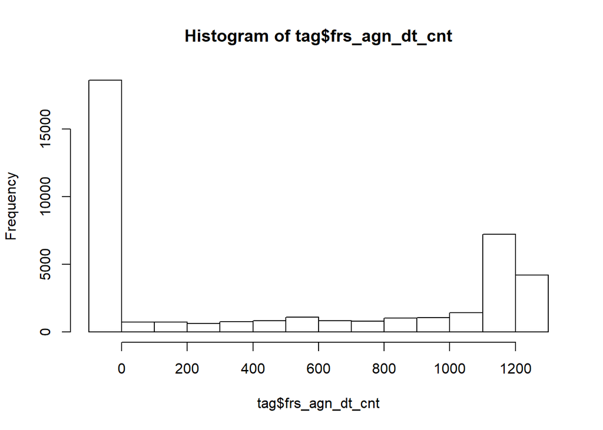

```r
#remove -1 in perm_crd_lmt_cd
dat1 <- subset(dat1, perm_crd_lmt_cd != -1)

#check frs_agn_dt_cnt
hist(tag$frs_agn_dt_cnt)
```

```r
summary(tag$l6mon_agn_ind)
```

```
##     0     1
## 26965 13035
```

```r
length(which(tag$frs_agn_dt_cnt == -1)) #=18588
```

```
## [1] 18588
```

```r
length(which(tag$frs_agn_dt_cnt == -1 & tag$l6mon_agn_ind == 0)) #=18528
```

```
## [1] 18528
```

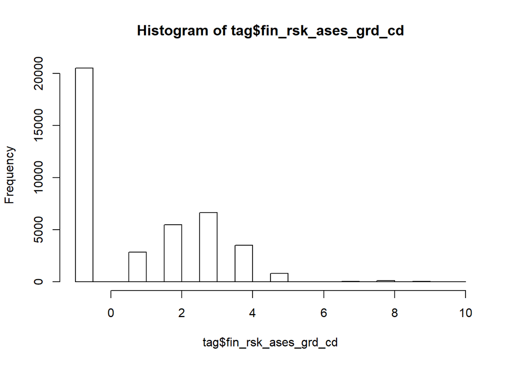

```r
#remove frs_agn_dt_cnt
dat1 <- subset(dat1, select = - frs_agn_dt_cnt)

#check fin_rsk_ases_grd_cd
hist(tag$fin_rsk_ases_grd_cd)
```

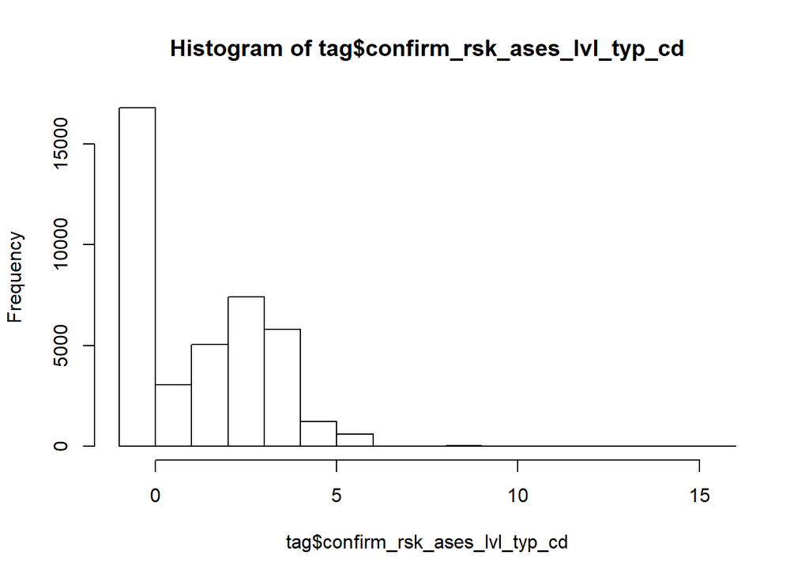

```r
#code the variable as a factor
dat1$fin_rsk_ases_grd_cd <- as.factor(dat1$fin_rsk_ases_grd_cd)

#check confirm_rsk_ases_lvl_typ_cd
hist(tag$confirm_rsk_ases_lvl_typ_cd)
```

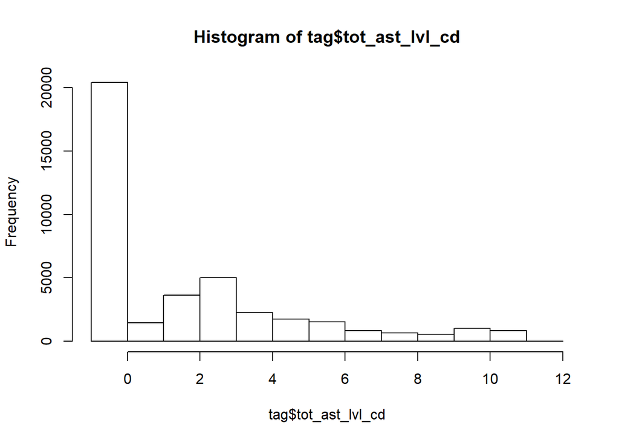

```r
#code the variable as a factor
dat1$confirm_rsk_ases_lvl_typ_cd <- as.factor(dat1$confirm_rsk_ases_lvl_typ_cd)

#check tot_ast_lvl_cd
hist(tag$tot_ast_lvl_cd)
```

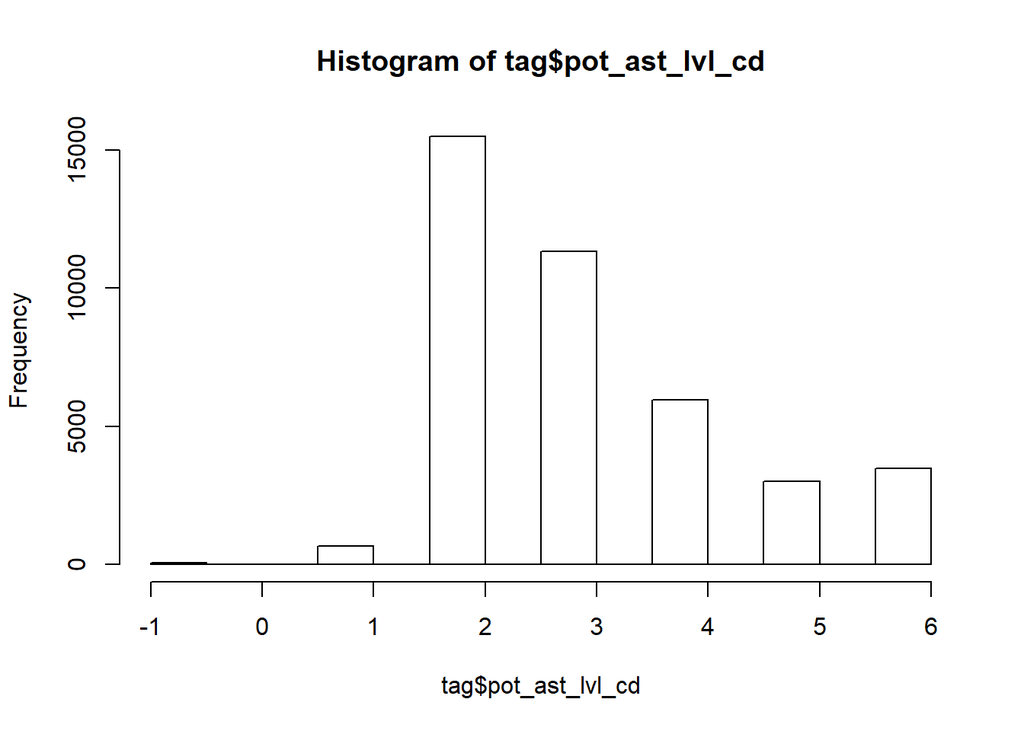

```r
#code the variable as a factor
dat1$tot_ast_lvl_cd <- as.factor(dat1$tot_ast_lvl_cd)

#check pot_ast_lvl_cd
hist(tag$pot_ast_lvl_cd)
```

```r
#code the variable as a factor
dat1$pot_ast_lvl_cd <- as.factor(dat1$pot_ast_lvl_cd)

#code "" levels as "-1"
levels(tag$atdd_type) <- c("-1", "-1", "0", "1")
levels(tag$deg_cd) <- c("-1",  "~", "A", "B", "C", "D", "E", "Z")
levels(tag$edu_deg_cd) <- c("-1",  "~", "A", "B", "C", "D", "E", "F", "G", "J", "K", "L", "M", "Z")
```

modify response variable:

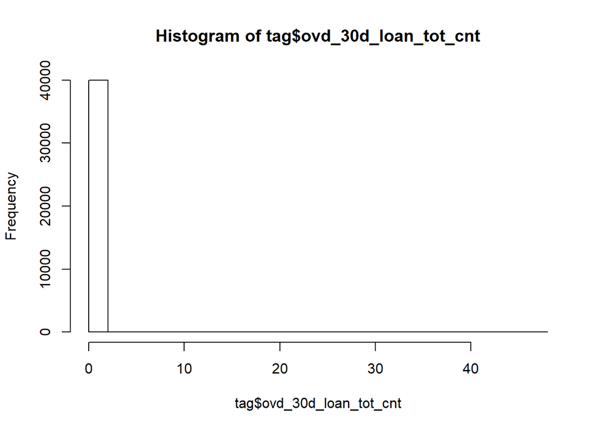

```r
#response variable
hist(tag$ovd_30d_loan_tot_cnt)
```

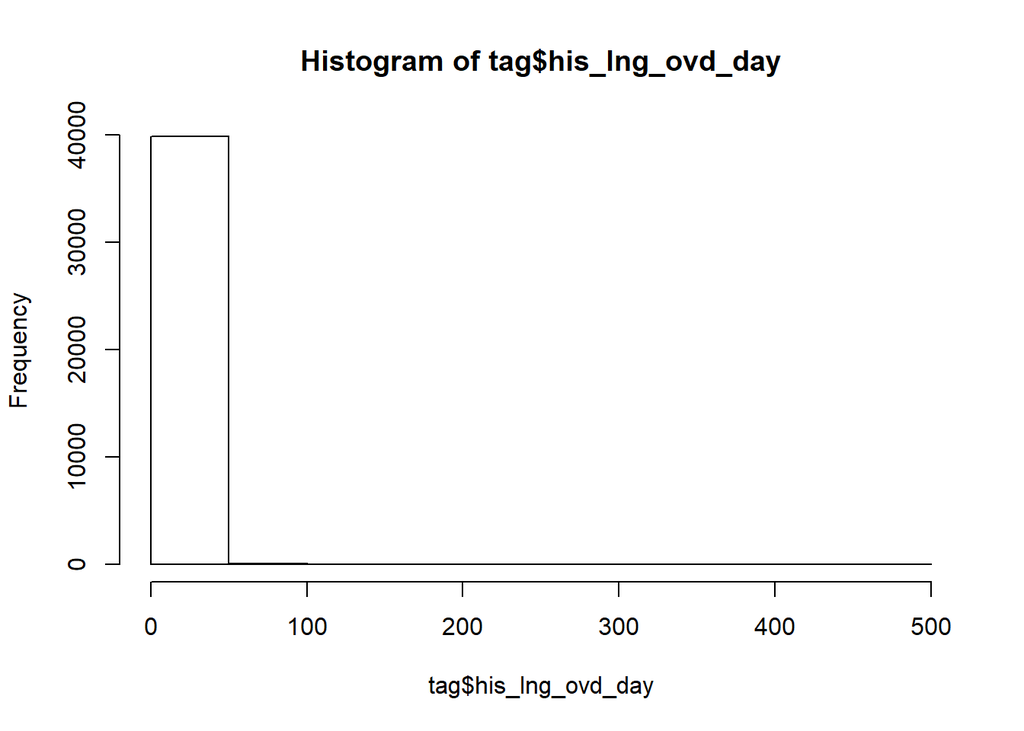

```r
#default for loan + credit card
hist(tag$his_lng_ovd_day)
```

```r
length(which(tag$his_lng_ovd_day != 0))
```

```
## [1] 3044
```

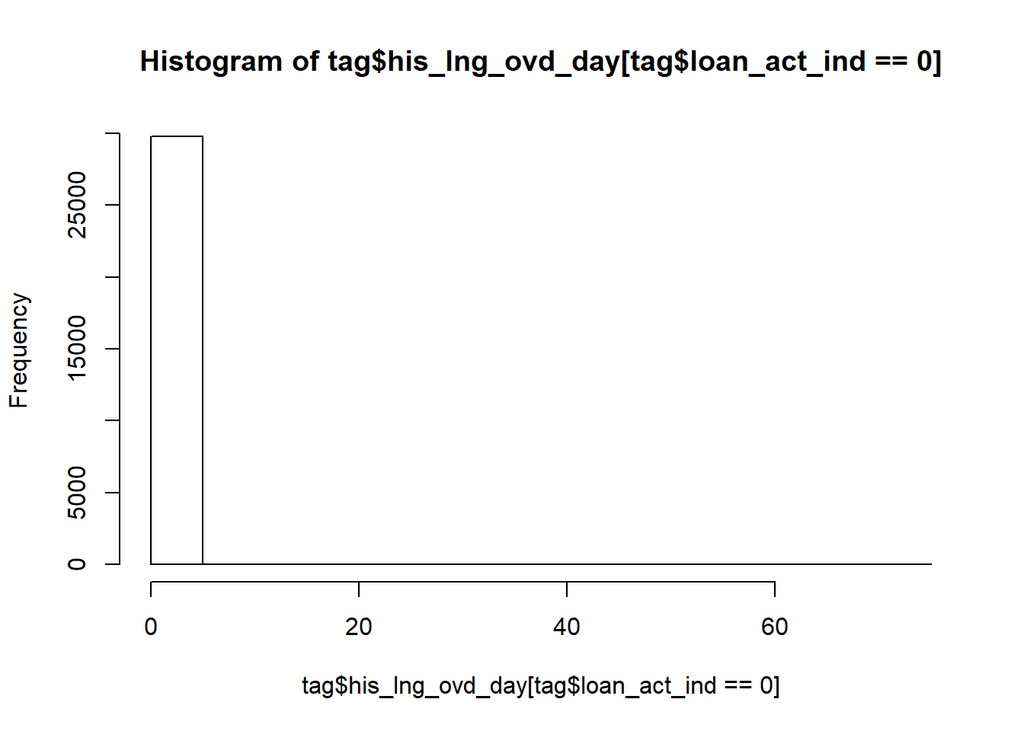

```r
#default for credit card (customers without loan)
hist(tag$his_lng_ovd_day[tag$loan_act_ind==0])
```

```r
#try to exclude customers with loan
dat1.1 <- dat1[dat1$loan_act_ind==0,]
length(which(dat1.1$his_lng_ovd_day > 0)) #only 3
```

```
## [1] 3
```

```r
length(which(dat1.1$ovd_30d_loan_tot_cnt > 0)) #only 1 person
```

```
## [1] 1
```

```r
#define Good as customers who never default
dat1$good <- as.factor(ifelse(dat1$his_lng_ovd_day == 0, 1, 0)) #Good as 1, Bad as 0
summary(dat1$good)
```

```
##     0     1
##  2997 36564
```

identify our target group: married women under 35

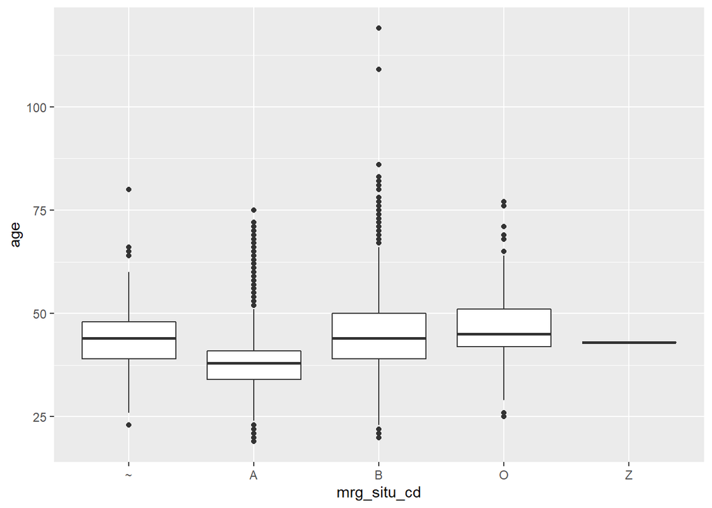

```r
#investigate mrg_situ_cd
ggplot(dat1, aes(x=mrg_situ_cd, y=age)) + geom_boxplot()
```

```r
attach(dat1)
mean(age[mrg_situ_cd=="A" & gdr_cd == "M"])
```

```
## [1] 36.48186
```

```r
mean(age[mrg_situ_cd=="B" & gdr_cd == "M"])
```

```
## [1] 44.8465
```

```r
detach()
#assume A = single, B = married

#subset our target group
dat.t <- subset(dat1, age<=35 & gdr_cd=="F" & mrg_situ_cd=="B", select = -c(age, gdr_cd, mrg_situ_cd))
dim(dat.t)
```

```
## [1] 856  40
```

```r
summary(dat.t)
```

```
##         id      flag      edu_deg_cd  acdm_deg_cd     deg_cd
##  U10023  :  1   0:574   B      :244   30:195      ~      :532
##  U1031042:  1   1:282   C      :209   31:276             :263
##  U10327  :  1           F      :168   C : 32      A      : 29
##  U1040544:  1           K      :120   D :  2      B      : 17
##  U1042174:  1           Z      : 52   F : 32      C      :  9
##  U1052178:  1           A      : 33   G :246      Z      :  6
##  (Other) :850           (Other): 30   Z : 73      (Other):  0
##     job_year      ic_ind  fr_or_sh_ind dnl_mbl_bnk_ind dnl_bind_cmb_lif_ind
##  Min.   : 0.000   0:798   0:687        0:  0           0: 81
##  1st Qu.: 0.000   1: 58   1:169        1:856           1:775
##  Median : 1.000
##  Mean   : 2.116
##  3rd Qu.: 3.000
##  Max.   :20.000
##
##  hav_car_grp_ind hav_hou_grp_ind l6mon_agn_ind vld_rsk_ases_ind
##  0:326           0:812           0:631         0:480
##  1:530           1: 44           1:225         1:376
##
##
##
##
##
##  fin_rsk_ases_grd_cd confirm_rsk_ases_lvl_typ_cd cust_inv_rsk_endu_lvl_cd
##  -1     :480         -1     :371                 Min.   :1.000
##  2      :132         2      :163                 1st Qu.:1.000
##  1      :126         1      :131                 Median :1.000
##  3      : 89         3      :128                 Mean   :1.569
##  4      : 26         4      : 53                 3rd Qu.:1.000
##  5      :  3         5      :  8                 Max.   :9.000
##  (Other):  0         (Other):  2
##  l6mon_daim_aum_cd tot_ast_lvl_cd pot_ast_lvl_cd
##  Min.   :1.00      -1     :495    -1:  5
##  1st Qu.:1.00      2      :114    1 :  7
##  Median :2.00      3      : 89    2 :203
##  Mean   :2.39      1      : 43    3 :222
##  3rd Qu.:3.00      4      : 34    4 :193
##  Max.   :9.00      5      : 29    5 :135
##                    (Other): 52    6 : 91
```

[output cut: 33 more lines]

```
##  Min.   :1.00    Min.   : 1.00   Min.   : 1.00   Min.   :  12.0
##  1st Qu.:3.00    1st Qu.: 1.00   1st Qu.: 1.00   1st Qu.: 902.2
##  Median :5.00    Median : 2.00   Median : 1.00   Median :2168.0
##  Mean   :4.71    Mean   : 2.02   Mean   : 1.63   Mean   :2312.7
##  3rd Qu.:7.00    3rd Qu.: 2.00   3rd Qu.: 2.00   3rd Qu.:3582.5
##  Max.   :8.00    Max.   :24.00   Max.   :10.00   Max.   :7986.0
##
##  cur_credit_min_opn_dt_cnt cur_debit_crd_lvl good
##  Min.   :   1              Min.   :10.00     0: 33
##  1st Qu.: 832              1st Qu.:10.00     1:823
##  Median :1748              Median :10.00
##  Mean   :2023              Mean   :15.82
##  3rd Qu.:3202              3rd Qu.:20.00
##  Max.   :5629              Max.   :80.00
##
```

Some conclusions can be drawn from this summary:

- our target group is very active in digital banking: they have all downloaded the bank’s app (variable dnl_mbl_bnk_ind), 90.5% of them have downloaded the special app for credit card (variable dnl_bind_cmb_lif_ind)
- 85.9% of them are active credit card users (indicated by the variable crd_card_act_ind). However, only 16.4% of them have loans with CMB.
- 3.85% of them have defaulted, much smaller than the proportion that defaulted in the overall dataset (7.57%)

Some variables are highly skewed

- bk1_cur_year_mon_avg_agn_amt_cd
- l12mon_buy_fin_mng_whl_tms
- l12_mon_fnd_buy_whl_tms
- l12_mon_insu_buy_whl_tms
- l12_mon_gld_buy_whl_tms

```r
#investigate some outliers in variables
which.max(dat.t$cur_credit_cnt) #143
```

```
## [1] 143
```

```r
dat.t[143,]
```

```
##          id flag edu_deg_cd acdm_deg_cd deg_cd job_year ic_ind fr_or_sh_ind
## 6991 U34630    0          A           C      ~        0      1            1
##      dnl_mbl_bnk_ind dnl_bind_cmb_lif_ind hav_car_grp_ind hav_hou_grp_ind
## 6991               1                    1               1               0
##      l6mon_agn_ind vld_rsk_ases_ind fin_rsk_ases_grd_cd
## 6991             1                1                   3
##      confirm_rsk_ases_lvl_typ_cd cust_inv_rsk_endu_lvl_cd l6mon_daim_aum_cd
## 6991                           3                        5                 8
##      tot_ast_lvl_cd pot_ast_lvl_cd bk1_cur_year_mon_avg_agn_amt_cd
## 6991              4              1                               5
##      l12mon_buy_fin_mng_whl_tms l12_mon_fnd_buy_whl_tms
## 6991                         57                       1
##      l12_mon_insu_buy_whl_tms l12_mon_gld_buy_whl_tms loan_act_ind
## 6991                        0                       0            1
##      pl_crd_lmt_cd ovd_30d_loan_tot_cnt his_lng_ovd_day hld_crd_card_grd_cd
## 6991             5                    0               0                  60
##      crd_card_act_ind l1y_crd_card_csm_amt_dlm_cd atdd_type perm_crd_lmt_cd
## 6991                1                           5         0               8
##      cur_debit_cnt cur_credit_cnt cur_debit_min_opn_dt_cnt
## 6991             6             10                     4229
##      cur_credit_min_opn_dt_cnt cur_debit_crd_lvl good
## 6991                      2104                60    1
```

```r
which.max(dat.t$his_lng_ovd_day) #298
```

```
## [1] 298
```

```r
dat.t[298,]
```

```
##             id flag edu_deg_cd acdm_deg_cd deg_cd job_year ic_ind fr_or_sh_ind
## 14623 U1184389    1          C          31      ~        1      0            0
##       dnl_mbl_bnk_ind dnl_bind_cmb_lif_ind hav_car_grp_ind hav_hou_grp_ind
## 14623               1                    0               1               0
##       l6mon_agn_ind vld_rsk_ases_ind fin_rsk_ases_grd_cd
## 14623             0                0                  -1
##       confirm_rsk_ases_lvl_typ_cd cust_inv_rsk_endu_lvl_cd l6mon_daim_aum_cd
## 14623                          -1                        1                 1
##       tot_ast_lvl_cd pot_ast_lvl_cd bk1_cur_year_mon_avg_agn_amt_cd
## 14623             -1              2                               0
##       l12mon_buy_fin_mng_whl_tms l12_mon_fnd_buy_whl_tms
## 14623                          0                       0
##       l12_mon_insu_buy_whl_tms l12_mon_gld_buy_whl_tms loan_act_ind
## 14623                        0                       0            1
##       pl_crd_lmt_cd ovd_30d_loan_tot_cnt his_lng_ovd_day hld_crd_card_grd_cd
## 14623             4                    2             165                  10
##       crd_card_act_ind l1y_crd_card_csm_amt_dlm_cd atdd_type perm_crd_lmt_cd
## 14623                1                           5                         7
##       cur_debit_cnt cur_credit_cnt cur_debit_min_opn_dt_cnt
## 14623             7              1                     1742
##       cur_credit_min_opn_dt_cnt cur_debit_crd_lvl good
## 14623                      2559                10    0
```

```r
#investigate the highly skewed variables
skew.df <- subset(dat.t, select = c(bk1_cur_year_mon_avg_agn_amt_cd, l12mon_buy_fin_mng_whl_tms,
                                    l12_mon_fnd_buy_whl_tms, l12_mon_insu_buy_whl_tms, l12_mon_gld_buy_whl_tms,
                                    pl_crd_lmt_cd, good))

#combine adjacent levels with similar Weight of Evidence
check_woe <- function(var) {
  tab.var <- table(as.factor(var), good)
  df.var <- as.data.frame.matrix(tab.var)
  df.prop.var <- as.data.frame.matrix(prop.table(tab.var, 1))
  df.var$woe <- log(df.prop.var$"1" / df.prop.var$"0")
  return(df.var)
}

attach(skew.df)
check_woe(bk1_cur_year_mon_avg_agn_amt_cd)
```

```
##     0   1       woe
## 0  27 606 3.1110431
## 1   0   9       Inf
## 2   0  29       Inf
## 3   0  55       Inf
## 4   3  55 2.9087209
## 5   0  39       Inf
## 6   0  22       Inf
## 7   2   5 0.9162907
## 8   1   2 0.6931472
## 10  0   1       Inf
```

```r
check_woe(l12mon_buy_fin_mng_whl_tms)
```

```
##     0   1      woe
## 0  30 730 3.191847
## 1   1  19 2.944439
## 2   0   9      Inf
## 3   0   4      Inf
## 4   1   3 1.098612
## 5   0   1      Inf
## 6   0  10      Inf
## 7   0   5      Inf
## 8   1   7 1.945910
## 9   0   4      Inf
## 10  0   2      Inf
## 11  0   5      Inf
## 12  0   2      Inf
## 13  0   1      Inf
```

[output cut: 16 more lines]

```r
check_woe(l12_mon_fnd_buy_whl_tms)
```

```
##      0   1       woe
## 0   26 618 3.1683919
## 1    1  65 4.1743873
## 2    2  19 2.2512918
## 3    1  14 2.6390573
## 4    0   8       Inf
## 5    0   8       Inf
## 6    0   7       Inf
## 7    0   7       Inf
## 8    0   2       Inf
## 9    0   6       Inf
## 10   0   8       Inf
## 11   0   2       Inf
## 12   0   3       Inf
## 13   0   2       Inf
```

[output cut: 36 more lines]

```r
check_woe(l12_mon_insu_buy_whl_tms)
```

```
##    0   1      woe
## 0 33 815 3.206681
## 1  0   8      Inf
```

```r
#too few people buy insurance （8 people buy once)

check_woe(l12_mon_gld_buy_whl_tms)
```

```
##      0   1      woe
## 0   33 818 3.210355
## 1    0   2      Inf
## 12   0   1      Inf
## 164  0   1      Inf
## 241  0   1      Inf
```

```r
#too few people buy gold (5 people buy >= 1 time)

check_woe(pl_crd_lmt_cd)
```

```
##   0   1       woe
## 0 4 724 5.1984970
## 1 0   1       Inf
## 2 1   4 1.3862944
## 3 8  21 0.9650809
## 4 8  17 0.7537718
## 5 4  38 2.2512918
## 6 7   8 0.1335314
## 7 0   5       Inf
## 8 0   5       Inf
## 9 1   0      -Inf
```

```r
detach()
```

```r
#drop levels
dat.t <- droplevels(dat.t)
summary(dat.t)
```

```
##         id      flag      edu_deg_cd  acdm_deg_cd deg_cd     job_year
##  U10023  :  1   0:574   B      :244   30:195       :263   Min.   : 0.000
##  U1031042:  1   1:282   C      :209   31:276      ~:532   1st Qu.: 0.000
##  U10327  :  1           F      :168   C : 32      A: 29   Median : 1.000
##  U1040544:  1           K      :120   D :  2      B: 17   Mean   : 2.116
##  U1042174:  1           Z      : 52   F : 32      C:  9   3rd Qu.: 3.000
##  U1052178:  1           A      : 33   G :246      Z:  6   Max.   :20.000
##  (Other) :850           (Other): 30   Z : 73
##  ic_ind  fr_or_sh_ind dnl_mbl_bnk_ind dnl_bind_cmb_lif_ind hav_car_grp_ind
##  0:798   0:687        1:856           0: 81                0:326
##  1: 58   1:169                        1:775                1:530
##
##
##
##
##
##  hav_hou_grp_ind l6mon_agn_ind vld_rsk_ases_ind fin_rsk_ases_grd_cd
##  0:812           0:631         0:480            -1:480
##  1: 44           1:225         1:376            1 :126
##                                                 2 :132
##                                                 3 : 89
##                                                 4 : 26
##                                                 5 :  3
##
##  confirm_rsk_ases_lvl_typ_cd cust_inv_rsk_endu_lvl_cd l6mon_daim_aum_cd
##  -1:371                      Min.   :1.000            Min.   :1.00
##  1 :131                      1st Qu.:1.000            1st Qu.:1.00
##  2 :163                      Median :1.000            Median :2.00
##  3 :128                      Mean   :1.569            Mean   :2.39
##  4 : 53                      3rd Qu.:1.000            3rd Qu.:3.00
##  5 :  8                      Max.   :9.000            Max.   :9.00
##  6 :  2
##  tot_ast_lvl_cd pot_ast_lvl_cd bk1_cur_year_mon_avg_agn_amt_cd
##  -1     :495    -1:  5         Min.   : 0.000
##  2      :114    1 :  7         1st Qu.: 0.000
##  3      : 89    2 :203         Median : 0.000
##  1      : 43    3 :222         Mean   : 1.021
##  4      : 34    4 :193         3rd Qu.: 1.250
##  5      : 29    5 :135         Max.   :10.000
##  (Other): 52    6 : 91
```

[output cut: 33 more lines]

```
##  Min.   : 1.00   Min.   :  12.0           Min.   :   1
##  1st Qu.: 1.00   1st Qu.: 902.2           1st Qu.: 832
##  Median : 1.00   Median :2168.0           Median :1748
##  Mean   : 1.63   Mean   :2312.7           Mean   :2023
##  3rd Qu.: 2.00   3rd Qu.:3582.5           3rd Qu.:3202
##  Max.   :10.00   Max.   :7986.0           Max.   :5629
##
##  cur_debit_crd_lvl good
##  Min.   :10.00     0: 33
##  1st Qu.:10.00     1:823
##  Median :10.00
##  Mean   :15.82
##  3rd Qu.:20.00
##  Max.   :80.00
##
```

```r
#select variables which reflect customer background and behaviour
dat.tf <- subset(dat.t, select = c(cur_debit_cnt, cur_credit_cnt, cur_debit_min_opn_dt_cnt, cur_credit_min_opn_dt_cnt, cur_debit_crd_lvl, hld_crd_card_grd_cd, crd_card_act_ind, l1y_crd_card_csm_amt_dlm_cd, atdd_type, perm_crd_lmt_cd, acdm_deg_cd, job_year, ic_ind, fr_or_sh_ind,
dnl_bind_cmb_lif_ind,
hav_car_grp_ind,
hav_hou_grp_ind,
l6mon_daim_aum_cd,
tot_ast_lvl_cd,
pot_ast_lvl_cd,
l12mon_buy_fin_mng_whl_tms,
l12_mon_fnd_buy_whl_tms,
l12_mon_insu_buy_whl_tms,
l12_mon_gld_buy_whl_tms,
loan_act_ind,
pl_crd_lmt_cd,
good))
summary(dat.tf)
```

```
##  cur_debit_cnt   cur_credit_cnt  cur_debit_min_opn_dt_cnt
##  Min.   : 1.00   Min.   : 1.00   Min.   :  12.0
##  1st Qu.: 1.00   1st Qu.: 1.00   1st Qu.: 902.2
##  Median : 2.00   Median : 1.00   Median :2168.0
##  Mean   : 2.02   Mean   : 1.63   Mean   :2312.7
##  3rd Qu.: 2.00   3rd Qu.: 2.00   3rd Qu.:3582.5
##  Max.   :24.00   Max.   :10.00   Max.   :7986.0
##
##  cur_credit_min_opn_dt_cnt cur_debit_crd_lvl hld_crd_card_grd_cd
##  Min.   :   1              Min.   :10.00     Min.   :10.00
##  1st Qu.: 832              1st Qu.:10.00     1st Qu.:10.00
##  Median :1748              Median :10.00     Median :20.00
##  Mean   :2023              Mean   :15.82     Mean   :16.68
##  3rd Qu.:3202              3rd Qu.:20.00     3rd Qu.:20.00
##  Max.   :5629              Max.   :80.00     Max.   :60.00
##
##  crd_card_act_ind l1y_crd_card_csm_amt_dlm_cd atdd_type perm_crd_lmt_cd
##  0:121            Min.   :0.000                :297     Min.   :1.00
##  1:735            1st Qu.:3.000               0:511     1st Qu.:3.00
##                   Median :4.000               1: 48     Median :5.00
##                   Mean   :3.326                         Mean   :4.71
##                   3rd Qu.:5.000                         3rd Qu.:7.00
##                   Max.   :5.000                         Max.   :8.00
##
##  acdm_deg_cd    job_year      ic_ind  fr_or_sh_ind dnl_bind_cmb_lif_ind
##  30:195      Min.   : 0.000   0:798   0:687        0: 81
##  31:276      1st Qu.: 0.000   1: 58   1:169        1:775
##  C : 32      Median : 1.000
##  D :  2      Mean   : 2.116
##  F : 32      3rd Qu.: 3.000
##  G :246      Max.   :20.000
##  Z : 73
##  hav_car_grp_ind hav_hou_grp_ind l6mon_daim_aum_cd tot_ast_lvl_cd
##  0:326           0:812           Min.   :1.00      -1     :495
##  1:530           1: 44           1st Qu.:1.00      2      :114
##                                  Median :2.00      3      : 89
##                                  Mean   :2.39      1      : 43
##                                  3rd Qu.:3.00      4      : 34
##                                  Max.   :9.00      5      : 29
##                                                    (Other): 52
```

[output cut: 9 more lines]

```
##  Min.   :0.000000         Min.   :  0.0000        0:715        Min.   :0.0000
##  1st Qu.:0.000000         1st Qu.:  0.0000        1:141        1st Qu.:0.0000
##  Median :0.000000         Median :  0.0000                     Median :0.0000
##  Mean   :0.009346         Mean   :  0.4895                     Mean   :0.6799
##  3rd Qu.:0.000000         3rd Qu.:  0.0000                     3rd Qu.:0.0000
##  Max.   :1.000000         Max.   :241.0000                     Max.   :9.0000
##
##  good
##  0: 33
##  1:823
##
##
##
##
##
```

edu_deg_cd, acdm_deg_cd, deg_cd are similar ideas. pick acdm_deg_cd because it has fewer levels than edu_deg_cd and more even distribution than deg_cd

2. From Initial to Final Model

```r
#raw model
glm.f <- glm(good~., data=dat.tf, family="binomial")
summary(glm.f)
```

```
##
## Call:
## glm(formula = good ~ ., family = "binomial", data = dat.tf)
##
## Deviance Residuals:
##      Min        1Q    Median        3Q       Max
## -2.78118   0.00000   0.00000   0.00001   2.04020
##
## Coefficients:
##                               Estimate Std. Error z value Pr(>|z|)
## (Intercept)                  2.715e+01  3.113e+04   0.001  0.99930
## cur_debit_cnt               -2.590e-01  1.431e-01  -1.810  0.07025 .
## cur_credit_cnt               6.116e-01  4.871e-01   1.256  0.20926
## cur_debit_min_opn_dt_cnt     3.222e-04  3.826e-04   0.842  0.39970
## cur_credit_min_opn_dt_cnt    3.072e-04  4.244e-04   0.724  0.46911
## cur_debit_crd_lvl           -1.460e-02  6.298e-02  -0.232  0.81672
## hld_crd_card_grd_cd         -9.997e-02  5.772e-02  -1.732  0.08330 .
## crd_card_act_ind1            1.146e+00  3.222e+00   0.356  0.72207
## l1y_crd_card_csm_amt_dlm_cd -7.294e-01  6.096e-01  -1.196  0.23150
## atdd_type0                   2.966e+00  1.134e+00   2.615  0.00892 **
## atdd_type1                  -4.710e-01  1.215e+00  -0.388  0.69817
## perm_crd_lmt_cd              2.831e-01  3.741e-01   0.757  0.44932
## acdm_deg_cd31               -2.601e+00  1.346e+00  -1.933  0.05327 .
## acdm_deg_cdC                 1.585e+01  1.021e+04   0.002  0.99876
## acdm_deg_cdD                -6.285e+00  5.278e+04   0.000  0.99990
## acdm_deg_cdF                -4.709e+00  1.929e+00  -2.442  0.01461 *
## acdm_deg_cdG                -3.443e+00  1.523e+00  -2.261  0.02375 *
## acdm_deg_cdZ                -3.729e+00  1.820e+00  -2.049  0.04049 *
## job_year                     2.688e-02  1.382e-01   0.194  0.84582
## ic_ind1                     -1.858e+00  1.421e+00  -1.308  0.19084
## fr_or_sh_ind1                7.623e-01  1.277e+00   0.597  0.55066
## dnl_bind_cmb_lif_ind1       -7.917e-01  1.863e+00  -0.425  0.67085
## hav_car_grp_ind1             7.449e-01  9.267e-01   0.804  0.42155
## hav_hou_grp_ind1            -3.200e+00  1.257e+00  -2.545  0.01093 *
## l6mon_daim_aum_cd            3.577e-01  4.434e-01   0.807  0.41984
## tot_ast_lvl_cd1              3.646e+00  3.598e+00   1.013  0.31086
## tot_ast_lvl_cd2              7.256e-01  1.281e+00   0.566  0.57122
## tot_ast_lvl_cd3              1.301e+00  1.542e+00   0.844  0.39887
## tot_ast_lvl_cd4              1.784e+01  1.013e+04   0.002  0.99859
## tot_ast_lvl_cd5             -3.059e+00  2.402e+00  -1.273  0.20290
```

[output cut: 13 more lines]

```
## l12_mon_fnd_buy_whl_tms     -6.902e-02  4.195e-02  -1.645  0.09989 .
## l12_mon_insu_buy_whl_tms     1.435e+01  1.901e+04   0.001  0.99940
## l12_mon_gld_buy_whl_tms      2.128e-02  2.364e+02   0.000  0.99993
## loan_act_ind1               -2.305e+01  2.238e+03  -0.010  0.99178
## pl_crd_lmt_cd               -1.913e-01  2.402e-01  -0.796  0.42576
## ---
## Signif. codes:  0 '***' 0.001 '**' 0.01 '*' 0.05 '.' 0.1 ' ' 1
##
## (Dispersion parameter for binomial family taken to be 1)
##
##     Null deviance: 279.591  on 855  degrees of freedom
## Residual deviance:  73.738  on 808  degrees of freedom
## AIC: 169.74
##
## Number of Fisher Scoring iterations: 22
```

```r
#classification table
ct.op <- function(predicted, observed) {
  df.op <- data.frame(predicted = predicted, observed = observed)
  # create a table
  op.tab <- table(df.op)
  # use the prop.table function to obtain the rows we need and stack them on
  # top of each other with rbind
  op.tab <- rbind(op.tab, c(round(prop.table(op.tab, 2)[1, 1], 2), round((prop.table(op.tab,2)[2, 2]), 2)))
  # name the rows
  rownames(op.tab) <- c("pred=0", "pred=1", "%corr")
  # name the columns
  colnames(op.tab) <- c("obs=0", "obs=1")
  # return the table
  op.tab
}
ct.op(as.numeric(glm.f$fitted.values>0.5), dat.tf$good)
```

```
##        obs=0  obs=1
## pred=0 25.00   5.00
## pred=1  8.00 818.00
## %corr   0.76   0.99
```

```r
#automatic model selection by AIC
glm.n <- glm(good~1, data=dat.tf, family="binomial")

glm.fwd <- step(glm.n, scope = list(lower = glm.n, upper = glm.f),
             direction = "forward", trace = 0)
```

[output not shown]

[output cut: 84 more lines]

[output not shown]

```r
ct.op(as.numeric(glm.fwd$fitted.values>0.5), dat.tf$good)
```

```
##        obs=0 obs=1
## pred=0 11.00     4
## pred=1 22.00   819
## %corr   0.33     1
```

```r
glm.bwd <- step(glm.f, direction = "backward", trace = 0)
```

[output not shown]

[output cut: 516 more lines]

[output not shown]

```r
summary(glm.bwd)
```

```
##
## Call:
## glm(formula = good ~ cur_debit_cnt + cur_credit_cnt + hld_crd_card_grd_cd +
##     l1y_crd_card_csm_amt_dlm_cd + atdd_type + perm_crd_lmt_cd +
##     acdm_deg_cd + ic_ind + hav_hou_grp_ind + pot_ast_lvl_cd +
##     l12mon_buy_fin_mng_whl_tms + l12_mon_fnd_buy_whl_tms + loan_act_ind,
##     family = "binomial", data = dat.tf)
##
## Deviance Residuals:
##      Min        1Q    Median        3Q       Max
## -2.22787   0.00000   0.00001   0.00002   2.94229
##
## Coefficients:
##                               Estimate Std. Error z value Pr(>|z|)
## (Intercept)                  2.718e+01  1.962e+04   0.001 0.998895
## cur_debit_cnt               -1.901e-01  9.407e-02  -2.021 0.043256 *
## cur_credit_cnt               5.484e-01  3.651e-01   1.502 0.133095
## hld_crd_card_grd_cd         -7.783e-02  4.409e-02  -1.765 0.077540 .
## l1y_crd_card_csm_amt_dlm_cd -5.716e-01  2.797e-01  -2.044 0.041000 *
## atdd_type0                   2.730e+00  8.088e-01   3.376 0.000736 ***
## atdd_type1                  -1.692e-01  1.003e+00  -0.169 0.865995
## perm_crd_lmt_cd              4.128e-01  3.000e-01   1.376 0.168776
## acdm_deg_cd31               -2.224e+00  1.032e+00  -2.155 0.031125 *
## acdm_deg_cdC                 1.819e+01  5.770e+03   0.003 0.997485
## acdm_deg_cdD                -4.151e+00  3.394e+04   0.000 0.999902
## acdm_deg_cdF                -5.312e+00  1.713e+00  -3.101 0.001931 **
## acdm_deg_cdG                -3.678e+00  1.214e+00  -3.030 0.002448 **
## acdm_deg_cdZ                -3.678e+00  1.509e+00  -2.437 0.014807 *
## ic_ind1                     -1.462e+00  8.061e-01  -1.814 0.069665 .
## hav_hou_grp_ind1            -1.929e+00  8.062e-01  -2.393 0.016723 *
## pot_ast_lvl_cd1             -3.841e+00  2.456e+04   0.000 0.999875
## pot_ast_lvl_cd2             -9.837e-01  1.967e+04   0.000 0.999960
## pot_ast_lvl_cd3              7.640e-02  1.967e+04   0.000 0.999997
## pot_ast_lvl_cd4              1.788e+00  1.967e+04   0.000 0.999927
## pot_ast_lvl_cd5             -4.920e-01  1.967e+04   0.000 0.999980
## pot_ast_lvl_cd6             -2.189e+00  1.967e+04   0.000 0.999911
## l12mon_buy_fin_mng_whl_tms   3.165e-01  2.016e-01   1.570 0.116517
## l12_mon_fnd_buy_whl_tms     -5.951e-02  2.953e-02  -2.015 0.043882 *
## loan_act_ind1               -2.289e+01  1.372e+03  -0.017 0.986685
## ---
## Signif. codes:  0 '***' 0.001 '**' 0.01 '*' 0.05 '.' 0.1 ' ' 1
##
## (Dispersion parameter for binomial family taken to be 1)
##
##     Null deviance: 279.59  on 855  degrees of freedom
## Residual deviance:  88.35  on 831  degrees of freedom
## AIC: 138.35
##
## Number of Fisher Scoring iterations: 21
```

```r
ct.op(as.numeric(glm.bwd$fitted.values>0.5), dat.tf$good)
```

```
##        obs=0  obs=1
## pred=0 19.00   7.00
## pred=1 14.00 816.00
## %corr   0.58   0.99
```

```r
glm.bi <- step(glm.f, direction = "both", trace = 0)
```

[output not shown]

[output cut: 724 more lines]

[output not shown]

```r
summary(glm.bi)
```

```
##
## Call:
## glm(formula = good ~ cur_debit_cnt + cur_credit_cnt + hld_crd_card_grd_cd +
##     l1y_crd_card_csm_amt_dlm_cd + atdd_type + perm_crd_lmt_cd +
##     acdm_deg_cd + ic_ind + hav_hou_grp_ind + pot_ast_lvl_cd +
##     l12mon_buy_fin_mng_whl_tms + l12_mon_fnd_buy_whl_tms + loan_act_ind,
##     family = "binomial", data = dat.tf)
##
## Deviance Residuals:
##      Min        1Q    Median        3Q       Max
## -2.22787   0.00000   0.00001   0.00002   2.94229
##
## Coefficients:
##                               Estimate Std. Error z value Pr(>|z|)
## (Intercept)                  2.718e+01  1.962e+04   0.001 0.998895
## cur_debit_cnt               -1.901e-01  9.407e-02  -2.021 0.043256 *
## cur_credit_cnt               5.484e-01  3.651e-01   1.502 0.133095
## hld_crd_card_grd_cd         -7.783e-02  4.409e-02  -1.765 0.077540 .
## l1y_crd_card_csm_amt_dlm_cd -5.716e-01  2.797e-01  -2.044 0.041000 *
## atdd_type0                   2.730e+00  8.088e-01   3.376 0.000736 ***
## atdd_type1                  -1.692e-01  1.003e+00  -0.169 0.865995
## perm_crd_lmt_cd              4.128e-01  3.000e-01   1.376 0.168776
## acdm_deg_cd31               -2.224e+00  1.032e+00  -2.155 0.031125 *
## acdm_deg_cdC                 1.819e+01  5.770e+03   0.003 0.997485
## acdm_deg_cdD                -4.151e+00  3.394e+04   0.000 0.999902
## acdm_deg_cdF                -5.312e+00  1.713e+00  -3.101 0.001931 **
## acdm_deg_cdG                -3.678e+00  1.214e+00  -3.030 0.002448 **
## acdm_deg_cdZ                -3.678e+00  1.509e+00  -2.437 0.014807 *
## ic_ind1                     -1.462e+00  8.061e-01  -1.814 0.069665 .
## hav_hou_grp_ind1            -1.929e+00  8.062e-01  -2.393 0.016723 *
## pot_ast_lvl_cd1             -3.841e+00  2.456e+04   0.000 0.999875
## pot_ast_lvl_cd2             -9.837e-01  1.967e+04   0.000 0.999960
## pot_ast_lvl_cd3              7.640e-02  1.967e+04   0.000 0.999997
## pot_ast_lvl_cd4              1.788e+00  1.967e+04   0.000 0.999927
## pot_ast_lvl_cd5             -4.920e-01  1.967e+04   0.000 0.999980
## pot_ast_lvl_cd6             -2.189e+00  1.967e+04   0.000 0.999911
## l12mon_buy_fin_mng_whl_tms   3.165e-01  2.016e-01   1.570 0.116517
## l12_mon_fnd_buy_whl_tms     -5.951e-02  2.953e-02  -2.015 0.043882 *
## loan_act_ind1               -2.289e+01  1.372e+03  -0.017 0.986685
## ---
## Signif. codes:  0 '***' 0.001 '**' 0.01 '*' 0.05 '.' 0.1 ' ' 1
##
## (Dispersion parameter for binomial family taken to be 1)
##
##     Null deviance: 279.59  on 855  degrees of freedom
## Residual deviance:  88.35  on 831  degrees of freedom
## AIC: 138.35
##
## Number of Fisher Scoring iterations: 21
```

```r
ct.op(as.numeric(glm.bi$fitted.values>0.5), dat.tf$good)
```

```
##        obs=0  obs=1
## pred=0 19.00   7.00
## pred=1 14.00 816.00
## %corr   0.58   0.99
```